# Remove blanks

# Load

Load libraries

```r
library(phyloseq)
library(tidyverse)
library(ggplot2)
library(cowplot)
library(vegan)
library(decontam)
```

Load data

```r
dir_data <- '/Users/lauragivens/Desktop/R/BZrookery_eDNA/Rdata'
dir_results <- "/Volumes/Fuji/Mangroves/2025_0319_Givens_Canty_Rookery_COI/cutadapt/results"

ps <- readRDS(paste0(dir_results,"/ps.rds"))
ps.troph <- readRDS(paste0(dir_results,"/ps.troph.rds"))

taxa <- readRDS(paste0(dir_results,"/taxtable.rds"))
taxa_troph <- readRDS(paste0(dir_results,"/taxtable.wtroph.rds"))
curated_lulu <- readRDS(paste0(dir_results,'/lulu-clustertable.rds'))
curated_asv <- readRDS(paste0(dir_results,"/asvtable.rds"))
samplelist <- readRDS(paste0(dir_results,'/metadata.rds'))
```

Alternatively, load working environment:

```r
load(paste0(dir_data,'/07_Blanks.RData'))
```

```r
troph_edit <- taxa_troph %>% mutate(.,
                      Trophic.Base = word(Trophic.Index,sep=" ") %>% as.numeric(),
                      Trophic.Round = round(as.numeric(Trophic.Base)),
                      .after = Trophic.Index
                      )

tax_table(ps.troph) <- as.matrix(troph_edit)

samplelist[samplelist==""] <- NA
samplelist[samplelist=="."] <- NA
samplelist$Date <- lubridate::dmy(samplelist$Date)
samplelist$Date_Extracted <- lubridate::dmy(samplelist$Date_Extracted)
samplelist$Quant_nguL <- as.numeric(samplelist$Quant_nguL) %>% round(digits = 2)
samplelist$Quant_nguL[is.na(samplelist$Quant_nguL)] <- 0
#samplelist$Month <- lubridate::month(samplelist$Date)
samplelist <- samplelist %>% mutate(.,
                                    Rookery=case_when(Rookery=="R" ~ "Rookery",
                                                      Rookery=="NR" ~ "Non-rookery",
                                                      Rookery=="Blank" ~ "Blank",
                                                      Rookery=="Practice" ~ "Practice"),
                                    Site=case_when(Site=="HI" ~ "Hicks Caye",
                                                   Site=="TA" ~ "Turneffe Atoll",
                                                   Site=="DC" ~ "Drowned Caye",
                                                   Site=="Practice" ~ "Practice",
                                                   Site=="Extraction" ~ "Extraction",
                                                   Site=="Field" ~ "Field",
                                                   Site=="Lab" ~ "Lab",
                                                   Site=="PCR" ~ "PCR"),
                                    Side=case_when(Side=="L" ~ "Leeward",
                                                   Side=="W" ~ "Windward")
                                    )

sample_data(ps.troph) <- samplelist
```

# Blanks

Make a phyloseq object of only the blanks. How many sequences are in each?

```r
ps.blanks
```

```
phyloseq-class experiment-level object
otu_table()   OTU Table:         [ 61 taxa and 24 samples ]
sample_data() Sample Data:       [ 24 samples by 12 sample variables ]
tax_table()   Taxonomy Table:    [ 61 taxa by 32 taxonomic ranks ]
```

```r
sample_sums(ps.blanks) %>% sort()
```

```
24-Sep_ExtractionBlank_6 27-Jan_ExtractionBlank_7      22-Feb_FieldBlank_1 28-Jan_ExtractionBlank_8
                       0                        4                       17                       18
             PCR_Blank_4        23-May_LabBlank_1 21-Sep_ExtractionBlank_4      23-Feb_FieldBlank_2
                      18                       26                       27                       31
     23-Nov_FieldBlank_2      17-Aug_FieldBlank_2              PCR_Blank_1              PCR_Blank_5
                      33                       38                       40                       44
             PCR_Blank_2      23-May_FieldBlank_2 23-Sep_ExtractionBlank_5      15-Aug_FieldBlank_1
                      47                       59                       65                       66
18-Sep_ExtractionBlank_3        23-Nov_LabBlank_1              PCR_Blank_3        23-Feb_LabBlank_1
                      66                       83                       84                       94
16-Sep_ExtractionBlank_1      23-May_FieldBlank_1      23-Nov_FieldBlank_1 17-Sep_ExtractionBlank_2
                     134                      155                      175                     1063
```

## Percent of sequences/ASVs

How many ASVs are in the blanks?

```r
length(blank.asvs)
```

```
[1] 62
```

What percent of taxa do those ASVs comprise?

```r
ntaxa(prune_taxa(taxa_names(ps)%in%blank.asvs,ps)) / ntaxa(ps) * 100
```

```
[1] 6.237425
```

What percent of sequences do those ASVs comprise?

```r
sum(taxa_sums(prune_taxa(taxa_names(ps)%in%blank.asvs,ps))) / sum(taxa_sums(ps)) * 100
```

```
[1] 75.0759
```

And how many of those are in the blank samples themselves?

```r
sum(taxa_sums(ps.blanks)) / sum(taxa_sums(ps)) * 100
```

```
[1] 0.8330018
```

We want to identify what taxa are in the blanks, and whether it’s better to remove all blank ASVs from the dataset or do some other method.

## What taxa are in blanks

Are these useful/biologically relevant taxa? Or are they contaminants like human, feline, canine DNA?

```r
get_taxa_unique(ps.blanks,"Species")
```

```
 [1] "Sphyrna tiburo"            "Gerres cinereus"           "Haemulon sciurus"
 [4] "Xyrichtys martinicensis"   "Chloroscombrus chrysurus"  "Sphyrna mokarran"
 [7] "Evorthodus lyricus"        NA                          "Carcharhinus limbatus"
[10] "Hemiramphus balao"         "Antennarius striatus"      "Ophioblennius atlanticus"
[13] "Liopropoma rubre"          "Apogon planifrons"         "Acyrtus lanthanum"
[16] "Xyrichtys splendens"       "Harengula humeralis"       "Diodon hystrix"
[19] "Halichoeres bivittatus"    "Mugil rubrioculus"         "Carangoides bartholomaei"
[22] "Lutjanus synagris"         "Stegastes adustus"         "Hippocampus erectus"
[25] "Acanthurus coeruleus"      "Antennarius pauciradiatus"
```

Many of these are fisheries-relevant or otherwise target fish species.

So before removing them, we should take a look at what the best way to remove them would be.

## Compare blanks with high/low sample sums

Is there much of a difference in ASVs that are found in blanks with a higher or lower number of sequences?

```r
y[!y%in%x] #how many asvs are only in the >100 dataset
```

```
 [1] "sq17001" "sq19040" "sq1933"  "sq23127" "sq23810" "sq24688" "sq25733" "sq2692"  "sq2737"  "sq3025"
[11] "sq3145"  "sq4781"  "sq4796"  "sq5392"  "sq54336" "sq5448"  "sq6141"  "sq6353"  "sq6586"  "sq7870"
[21] "sq8379"  "sq863"   "sq9254"  "sq9425"
```

```r
x[!x%in%y] #how many asvs are only in the <100 dataset
```

```
 [1] "sq1294"  "sq1722"  "sq1749"  "sq18860" "sq19772" "sq2187"  "sq2228"  "sq2409"  "sq2447"  "sq2489"
[11] "sq2846"  "sq2976"  "sq3119"  "sq3180"  "sq4114"  "sq4459"  "sq4526"  "sq4968"  "sq752"   "sq7598"
[21] "sq8199"
```

Not really. Looking below, when we prune the dataset to only the blank ASVs, the spread is pretty similar regardless of whether they are from blanks with high or low abundance.

```r
sample_sums(ps.troph %>% prune_taxa(taxa_names(.)%in%x,.)) %>% summary()
```

```
   Min. 1st Qu.  Median    Mean 3rd Qu.    Max.
      0     160     462    1317    1138   28798
```

```r
sample_sums(ps.troph %>% prune_taxa(taxa_names(.)%in%y,.)) %>% summary()
```

```
   Min. 1st Qu.  Median    Mean 3rd Qu.    Max.
    0.0   134.8   374.0  1207.1   911.2 33121.0
```

compared to the blanks:

```r
sample_sums(ps.blanks) %>% summary()
```

```
   Min. 1st Qu.  Median    Mean 3rd Qu.    Max.
   0.00   26.75   45.50   99.46   83.25 1063.00
```

We are losing some taxa with pretty high abundances if we were to remove all ASVs found in the blanks.

## Compare taxa before and after blank removal

When we remove the ASVs from the blanks, it only removes the specific sequence. There could be other ASVs that are assigned to the same taxa, which would make losing those high-abundance ASVs more palatable. Here we are going to get the list of species found in the blanks, and compare sample sums of those species before and after removal. If the sample sums remain high/similar, then removing the specific ASVs found in the blanks are unlikely to have strong negative effects.

However, this isn’t what we find. Removal of blank ASVs isn’t compensated for with other ASVs, and the number of sequences still assigned to those taxa drops dramatically.

```r
ps.troph %>%  #sample sums when subset to only species in the blanks
  subset_taxa(.,Species%in%(get_taxa_unique(ps.blanks,"Species"))) %>%
  sample_sums() %>% summary()
```

```
   Min. 1st Qu.  Median    Mean 3rd Qu.    Max.
    0.0   251.5   774.5  1799.6  1999.8 33668.0
```

```r
(ps.troph %>% prune_taxa(!taxa_names(.)%in%taxa_names(ps.blanks),.)) %>%  #sample sums when subset to only species in the blanks
  subset_taxa(.,Species%in%(get_taxa_unique(ps.blanks,"Species"))) %>%
  sample_sums() %>% summary()
```

```
   Min. 1st Qu.  Median    Mean 3rd Qu.    Max.
    0.0    22.0   159.0   346.2   374.8  4122.0
```

# Decontamination

## Identify contaminants

Okay, so we have decided that carte blanche removing the ASVs that are found in our blanks would result in:  
1. *Removing important taxa* (species assigned to those ASVs are fish)  
2. *Seriously reducing the occurrence of key species in the samples* (other ASVs are not assigned to the same fish species with similar frequency)

And indeed this is a strategy that is generally seen as overly cautious and likely to remove biologically relevant data. (e.g., QIIME2 documentation, Nguyen et al., 2015 )

We could remove the number of sequences found in the blanks from each sample (again, see Nguyen et al., 2015) Or remove any ASVs below a certain relative abundance threshold (see background in Davis et al., 2018) Or use decontam R package, which uses the following principles:  
Sequences from contaminating taxa are likely to have frequencies that inversely correlate with sample DNA concentration [8, 14, 16, 30] and (2) sequences from contaminating taxa are likely to have higher prevalence in control samples than in true samples

So using decontam package…  
*Using the “frequency” method*, the distribution of the frequency of each sequence feature as a function of the input DNA concentration is used to identify contaminants.  
*Using the “prevalence” method*, the prevalence (presence/absence across samples) of each sequence feature in true positive samples is compared to the prevalence in negative controls to identify contaminants.

We’ll summarize the sample variable that holds the negative control information as a logical variable, with TRUE for control samples, as that is the form required by isContaminant.

```r
ps.decontam <- ps.troph %>% subset_samples(Site != "Practice") %>% prune_samples(sample_sums(.)>0,.)
sample_data(ps.decontam)$is.neg <- sample_data(ps.decontam)$Site == "Field"
sample_data(ps.decontam)$is.neg <- sample_data(ps.decontam)$Site == "Lab"
sample_data(ps.decontam)$is.neg <- sample_data(ps.decontam)$Site == "Extraction"

sample_data(ps.decontam)$Quant_nguL[sample_data(ps.decontam)$Quant_nguL==0] <- 0.000000001
# don't want to include the PCR blanks
```

```r
contamdf.freq <- isContaminant((ps.decontam %>% subset_samples(Quant_nguL>0)), method="frequency", conc="Quant_nguL")
contamdf.prev <- isContaminant(ps.decontam, method="prevalence", neg="is.neg")
```

#### Decontam: Concentration-based

What contaminants were identified based on DNA concentration?

|  | freq | prev | p.freq | p.prev | p | contaminant |
| --- | --- | --- | --- | --- | --- | --- |
| sq13406 | 1.678271e-04 | 4 | 0.084395770 | NA | 0.084395770 | TRUE |
| sq14578 | 5.100680e-04 | 4 | 0.046503913 | NA | 0.046503913 | TRUE |
| sq14854 | 2.762499e-04 | 5 | 0.080213235 | NA | 0.080213235 | TRUE |
| sq16567 | 2.396110e-04 | 4 | 0.056824887 | NA | 0.056824887 | TRUE |
| sq18785 | 5.898448e-05 | 2 | 0.010822792 | NA | 0.010822792 | TRUE |
| sq19684 | 1.447769e-04 | 2 | 0.002195866 | NA | 0.002195866 | TRUE |
| sq22803 | 9.619572e-05 | 2 | 0.053140863 | NA | 0.053140863 | TRUE |
| sq23200 | 4.260244e-04 | 3 | 0.051765087 | NA | 0.051765087 | TRUE |
| sq25809 | 9.005613e-05 | 2 | 0.088708013 | NA | 0.088708013 | TRUE |
| sq26205 | 3.160633e-04 | 4 | 0.094593192 | NA | 0.094593192 | TRUE |

[output cut: 8 more lines]

What taxa are those assigned to?

```r
ps.decontam %>% prune_taxa(taxa_names(.)%in%contamnames.freq,.) %>% tax_table() %>% as.matrix() %>% as.data.frame() %>% .[2:8]
```

|  | Phylum | Class | Order | Family | Genus | Species | taxid |
| --- | --- | --- | --- | --- | --- | --- | --- |
| sq13406 | Chordata | Actinopteri | Perciformes | Scorpaenidae | Pterois | Pterois volitans | 185886 |
| sq14578 | Chordata | Actinopteri | Blenniiformes | Blenniidae | Hypleurochilus | Hypleurochilus springeri | 345254 |
| sq14854 | Chordata | Actinopteri | Gobiiformes | Gobiidae | Bathygobius | Bathygobius curacao | 163632 |
| sq16567 | Chordata | Actinopteri | Pleuronectiformes | Cyclopsettidae | Citharichthys | Citharichthys spilopterus | 1154647 |
| sq18785 | Chordata | Actinopteri | Labriformes | Labridae | Xyrichtys | Xyrichtys splendens | 13766 |
| sq19684 | Chordata | Actinopteri | NA | Opistognathidae | Opistognathus | Opistognathus aurifrons | 390358 |
| sq22803 | Chordata | Actinopteri | Carangiformes | Carangidae | Caranx | Caranx hippos | 173312 |
| sq23200 | Chordata | Chondrichthyes | Carcharhiniformes | Carcharhinidae | Carcharhinus | Carcharhinus limbatus | 61865 |
| sq25809 | Chordata | Actinopteri | Holocentriformes | Holocentridae | Neoniphon | NA | 1182776 |
| sq26205 | Chordata | Actinopteri | NA | Pomacentridae | Stegastes | Stegastes planifrons | 159713 |

[output cut: 8 more lines]

What does that look like?

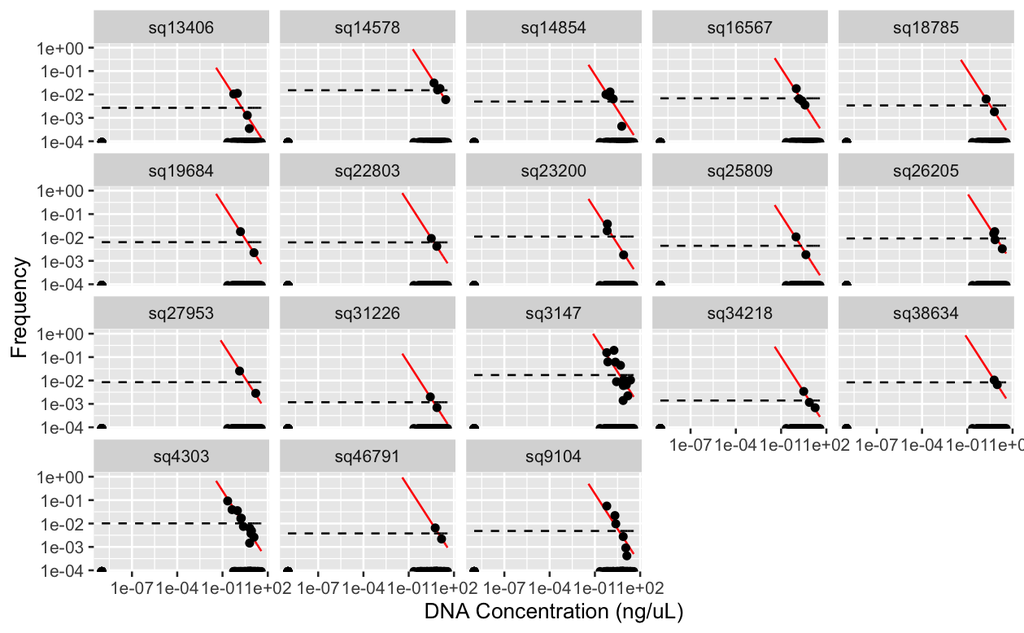

```r
plot_frequency((ps.decontam %>% subset_samples(Quant_nguL>0)),
               contamnames.freq, conc="Quant_nguL") +
  xlab("DNA Concentration (ng/uL)")
```

“In this plot the dashed black line shows the model of a noncontaminant sequence feature for which frequency is expected to be independent of the input DNA concentration. The red line shows the model of a contaminant sequence feature, for which frequency is expected to be inversely proportional to input DNA concentration, as contaminating DNA will make up a larger fraction of the total DNA in samples with very little total DNA.”  
So a falsely identified contaminant would not follow the red line very well

#### Decontam: Prevalence-based

What contaminants were identified based on prevalence?

|  | freq | prev | p.freq | p.prev | p | contaminant |
| --- | --- | --- | --- | --- | --- | --- |
| sq138 | 0.0968840907 | 57 | NA | 0.06163909 | 0.06163909 | TRUE |
| sq19040 | 0.0001098384 | 3 | NA | 0.07604612 | 0.07604612 | TRUE |
| sq23127 | 0.0002789159 | 3 | NA | 0.07604612 | 0.07604612 | TRUE |
| sq24688 | 0.0001469119 | 3 | NA | 0.07604612 | 0.07604612 | TRUE |
| sq2489 | 0.0024849111 | 6 | NA | 0.01584497 | 0.01584497 | TRUE |
| sq25733 | 0.0001487798 | 2 | NA | 0.05072464 | 0.05072464 | TRUE |

What taxa do those correspond to?

```r
ps.decontam %>% prune_taxa(taxa_names(.)%in%contamnames.prev,.) %>% tax_table() %>% as.matrix() %>% as.data.frame() %>% .[2:8]
```

|  | Phylum | Class | Order | Family | Genus | Species | taxid |
| --- | --- | --- | --- | --- | --- | --- | --- |
| sq138 | Chordata | Actinopteri | Labriformes | Labridae | Xyrichtys | Xyrichtys martinicensis | 13764 |
| sq19040 | Chordata | Chondrichthyes | Carcharhiniformes | Carcharhinidae | Prionace | NA | 7815 |
| sq23127 | Chordata | Actinopteri | Tetraodontiformes | Tetraodontidae | Sphoeroides | NA | 722567 |
| sq24688 | Chordata | Actinopteri | Blenniiformes | Gobiesocidae | Acyrtus | Acyrtus lanthanum | 1500689 |
| sq2489 | Chordata | Actinopteri | Labriformes | Labridae | Xyrichtys | Xyrichtys splendens | 13766 |
| sq25733 | Chordata | Actinopteri | Lutjaniformes | Lutjanidae | Lutjanus | NA | 40494 |

Visualize how many times sequences identified as contaminants were found in negatives versus positives

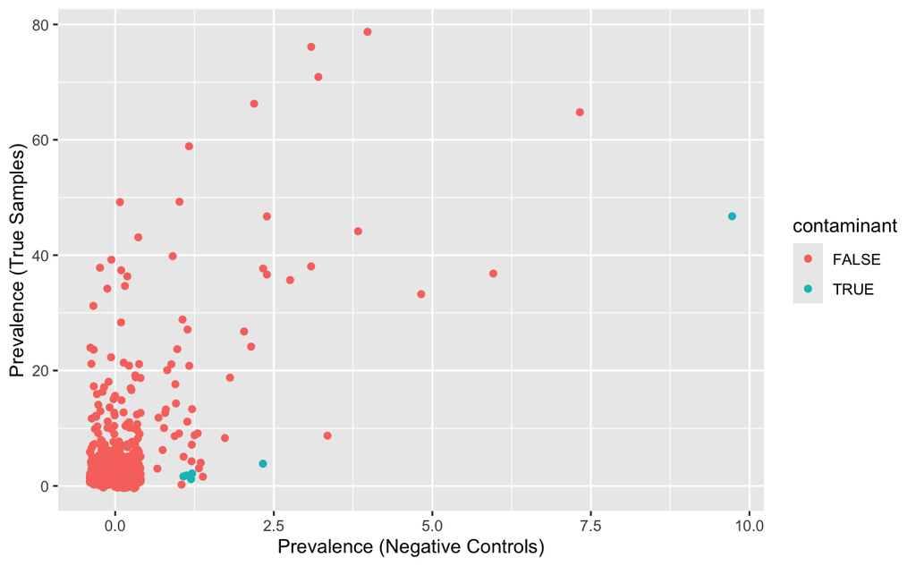

# Removal

## Contaminants

We are first going to use a combination of both decontam methods to remove contaminant ASVs from the ps object  
(method=combined,minimum, or both) Combined = probabilities of both are combined with Fisher’s method to identify contaminants Minimum = minimum of both probabilites is used to identify contaminants Either = contaminants are called if they are identified by either method  
Both = contaminants are called if they are identified by both methods

|  | freq | prev | p.freq | p.prev | p | contaminant |
| --- | --- | --- | --- | --- | --- | --- |
| sq18785 | 5.898448e-05 | 2 | 0.010822792 | 0.54961388 | 0.036431546 | TRUE |
| sq19684 | 1.447769e-04 | 2 | 0.002195866 | 0.54961388 | 0.009316762 | TRUE |
| sq2489 | 2.484911e-03 | 6 | 0.454362706 | 0.01584497 | 0.042719305 | TRUE |
| sq31226 | 1.944317e-05 | 2 | 0.022547292 | 0.54961388 | 0.066802944 | TRUE |
| sq38634 | 1.239372e-04 | 2 | 0.029238467 | 0.54961388 | 0.082451425 | TRUE |
| sq4303 | 1.640952e-03 | 11 | 0.001394518 | 0.72424488 | 0.007976592 | TRUE |

What was kept from the separate versions?  
Prevalence:

```r
contamdf.names[contamdf.names%in%contamnames.prev]
```

```
[1] "sq2489"
```

Frequency:

```r
contamdf.names[contamdf.names%in%contamnames.freq]
```

```
[1] "sq18785" "sq19684" "sq31226" "sq38634" "sq4303"
```

Curious if the one that was kept was the ASV with really high prevalence in the negative controls

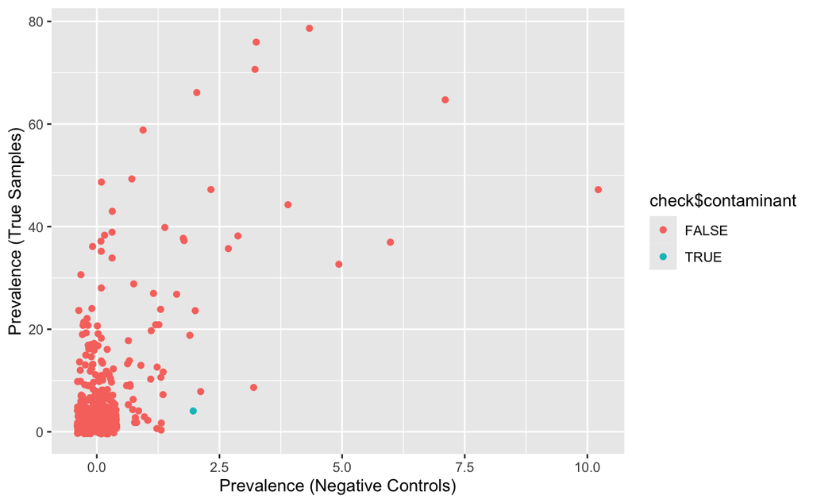

Weirdly enough, no that wasn’t the one that decontam decided was a contaminant.

Just for another double check, what does the plot look like for the combined decontam df?

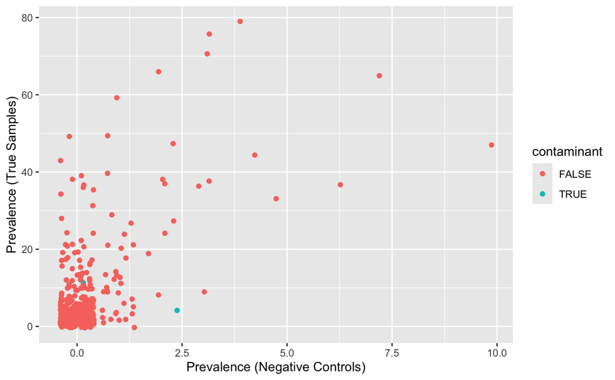

What percent of taxa do those ASVs comprise?

```r
length(contamdf.names) / ntaxa(ps) * 100
```

```
[1] 0.6036217
```

0.603% of taxa

What percent of sequences do those ASVs comprise?

```r
sum(taxa_sums(prune_taxa(taxa_names(ps)%in%contamdf.names,ps))) / sum(taxa_sums(ps)) * 100
```

```
[1] 0.2906956
```

0.29% of the sequences

```r
sample_sums(ps.troph %>% prune_taxa(taxa_names(.)%in%contamdf.names,.)) %>% summary()
```

```
   Min. 1st Qu.  Median    Mean 3rd Qu.    Max.
  0.000   0.000   0.000   5.628   0.000 276.000
```

```r
ps.troph
```

```
phyloseq-class experiment-level object
otu_table()   OTU Table:         [ 994 taxa and 148 samples ]
sample_data() Sample Data:       [ 148 samples by 12 sample variables ]
tax_table()   Taxonomy Table:    [ 994 taxa by 32 taxonomic ranks ]
```

```r
decontam.ps.troph
```

```
phyloseq-class experiment-level object
otu_table()   OTU Table:         [ 988 taxa and 148 samples ]
sample_data() Sample Data:       [ 148 samples by 12 sample variables ]
tax_table()   Taxonomy Table:    [ 988 taxa by 32 taxonomic ranks ]
```

## Blanks

After decontamination, we are next going to get a list of ASVs that appear in the blanks and their quantities, and remove that number from each sample from that site.

```r
ps.blanks <- decontam.ps.troph %>% subset_samples(.,Rookery=='Blank') %>% prune_taxa(taxa_sums(.)>0,.)
```

We have field blanks, lab blanks, extraction blanks, and PCR blanks.

```r
ps.blanks
```

```
phyloseq-class experiment-level object
otu_table()   OTU Table:         [ 61 taxa and 24 samples ]
sample_data() Sample Data:       [ 24 samples by 12 sample variables ]
tax_table()   Taxonomy Table:    [ 61 taxa by 32 taxonomic ranks ]
```

```r
ntaxa(ps.blanks)
```

```
[1] 61
```

```r
sample_sums(ps.blanks) %>% sort()
```

```
24-Sep_ExtractionBlank_6 27-Jan_ExtractionBlank_7      22-Feb_FieldBlank_1 28-Jan_ExtractionBlank_8
                       0                        4                       17                       18
             PCR_Blank_4        23-May_LabBlank_1 21-Sep_ExtractionBlank_4      23-Feb_FieldBlank_2
                      18                       26                       27                       31
     23-Nov_FieldBlank_2      17-Aug_FieldBlank_2              PCR_Blank_1              PCR_Blank_5
                      33                       38                       40                       44
             PCR_Blank_2      23-May_FieldBlank_2 23-Sep_ExtractionBlank_5      15-Aug_FieldBlank_1
                      47                       59                       65                       66
18-Sep_ExtractionBlank_3        23-Nov_LabBlank_1              PCR_Blank_3        23-Feb_LabBlank_1
                      66                       83                       84                       94
16-Sep_ExtractionBlank_1      23-May_FieldBlank_1      23-Nov_FieldBlank_1 17-Sep_ExtractionBlank_2
                     134                      155                      175                     1063
```

Remove ASVs from PCR blanks from all samples  
PCR blanks:

```r
ps.blanks %>% subset_samples(Site=="PCR") %>% prune_taxa(taxa_sums(.)>0,.) %>% otu_table()
```

```
OTU Table:          [19 taxa and 5 samples]
                     taxa are rows
       PCR_Blank_1 PCR_Blank_2 PCR_Blank_3 PCR_Blank_4 PCR_Blank_5
sq1042           8           0           0           0           0
sq1118           2           2           0           3           0
sq1294           0           0           0           0           4
sq138            0          43           0           0           0
sq1749           0           0          17           0           0
sq2187           0           0           3           0           0
sq2221           0           0          12           0           0
sq2228           0           0           0           0          13
sq2447           0           0           0           0          25
sq2846           0           0           0           2           0
sq303           28           0          39           0           0
sq3180           0           2           0           0           0
sq392            0           0           0           8           0
sq4114           0           0           0           0           2
sq4526           0           0           0           5           0
sq7598           2           0           0           0           0
sq8199           0           0           4           0           0
sq905            0           0           4           0           0
sq995            0           0           5           0           0
```

Remove ASVs from extraction blanks from their respective extraction day

```r
ps.blanks %>% subset_samples(Site=="Extraction")  %>% prune_taxa(taxa_sums(.)>0,.) %>% otu_table()
```

```
OTU Table:          [43 taxa and 8 samples]
                     taxa are rows
        16-Sep_ExtractionBlank_1 17-Sep_ExtractionBlank_2 18-Sep_ExtractionBlank_3
sq1042                         0                        6                        0
sq1118                         0                      127                        0
sq1191                         0                       13                        0
sq138                         57                       48                       40
sq1477                         0                        0                        0
sq17001                        0                        7                        0
sq1764                         0                      111                        0
sq1786                         2                        0                        0
sq1827                         0                        0                        0
sq18860                        0                        0                        0
sq19040                        0                        7                        0
sq1933                         0                        9                        0
sq2153                         4                       10                        0
sq2221                         6                        0                        0
sq2228                         0                        0                        0
sq23127                        0                       11                        0
sq23810                        0                        9                        0
sq2409                         0                        0                        0
sq24688                        0                        5                        0
sq25733                        0                       21                        0
sq2641                         0                        9                        0
sq2692                         0                      112                        0
sq2737                         0                        7                        0
sq2747                         0                       10                        0
sq3025                         0                       31                        0
sq303                         31                        4                       24
sq3119                         0                        0                        0
sq3145                         0                       97                        0
sq392                         32                      226                        0
sq4781                         0                       10                        0
sq4796                         0                       25                        0
sq4968                         0                        0                        0
sq5392                         0                        9                        0
sq54336                        0                        8                        0
sq5448                         0                        7                        0
sq6141                         0                       10                        0
sq6353                         0                       22                        0
```

[output cut: 79 more lines]

```
sq392                          0                        0
sq4781                         0                        0
sq4796                         0                        0
sq4968                         4                        0
sq5392                         0                        0
sq54336                        0                        0
sq5448                         0                        0
sq6141                         0                        0
sq6353                         0                        0
sq6586                         0                        0
sq7870                         0                        0
sq8379                         0                        0
sq905                          0                        0
sq9254                         0                        0
sq9425                         0                        0
```

Remove ASVs from field and lab blanks from their respective sample days

```r
ps.blanks %>% subset_samples(Site=="Lab" | Site=="Field")  %>% prune_taxa(taxa_sums(.)>0,.) %>% otu_table()
```

```
OTU Table:          [24 taxa and 11 samples]
                     taxa are rows
        15-Aug_FieldBlank_1 17-Aug_FieldBlank_2 22-Feb_FieldBlank_1 23-Feb_FieldBlank_2 23-Feb_LabBlank_1
sq1118                    0                   0                   0                   0                 0
sq1191                    0                   0                   0                   0                 5
sq138                    38                   0                   0                   0                 0
sq1477                    0                   0                   0                   0                 0
sq1722                    0                   0                   0                   0                 6
sq1749                    0                   0                   0                   0                 0
sq1764                    0                   0                   0                   0                 0
sq1786                    6                   0                   0                   0                 0
sq1827                    3                   3                   0                   0                 0
sq19772                   0                   0                   0                   0                 0
sq2153                    0                   0                   0                   0                 0
sq2409                    0                   0                   0                   0                 0
sq2447                    0                   0                   0                   0                18
sq2504                    0                   0                   0                   0                 3
sq2641                    0                   0                   0                   0                 0
sq2747                    0                   0                   5                   0                 0
sq2976                    0                   0                   0                   0                 9
sq303                    15                   0                   7                  31                 0
sq392                     0                   0                   0                   0                 0
sq4459                    0                   0                   0                   0                 0
sq752                     0                  35                   0                   0                33
sq863                     0                   0                   0                   0                 0
sq905                     0                   0                   5                   0                 0
sq995                     4                   0                   0                   0                20
        23-May_FieldBlank_1 23-May_FieldBlank_2 23-May_LabBlank_1 23-Nov_FieldBlank_1 23-Nov_FieldBlank_2
sq1118                    0                   0                 0                   6                   0
sq1191                    0                   0                 0                   0                   0
sq138                   124                   0                 0                 103                  27
sq1477                   10                   0                 0                   0                   0
sq1722                    0                   0                 0                   0                   0
sq1749                    0                   0                 0                   0                   0
sq1764                    0                   0                 0                   3                   0
sq1786                    0                   0                 0                   0                   0
sq1827                    4                   0                 0                   0                   0
sq19772                   0                   0                 0                   0                   0
sq2153                    0                   0                 5                   4                   3
sq2409                    0                   0                 0                   0                   3
```

[output cut: 22 more lines]

```
sq19772                 2
sq2153                  7
sq2409                  0
sq2447                  0
sq2504                  0
sq2641                  0
sq2747                  0
sq2976                  0
sq303                   0
sq392                  23
sq4459                  0
sq752                   0
sq863                   0
sq905                   0
sq995                   0
```

```r
ps.blanks %>% subset_samples(Site=="Lab" | Site=="Field") %>% sample_names()
```

```
 [1] "15-Aug_FieldBlank_1" "17-Aug_FieldBlank_2" "22-Feb_FieldBlank_1" "23-Feb_FieldBlank_2"
 [5] "23-Feb_LabBlank_1"   "23-May_FieldBlank_1" "23-May_FieldBlank_2" "23-May_LabBlank_1"
 [9] "23-Nov_FieldBlank_1" "23-Nov_FieldBlank_2" "23-Nov_LabBlank_1"
```

Going in order:

```r
prune_a.ps <- decontam.ps.troph
```

### Field and lab blanks

```r
sample_events <- ps.blanks %>% subset_samples(Site=="Lab" | Site=="Field") %>% get_variable(.,"Date") %>% unique()
```

Test:

```r
 a <- prune_a.ps %>% subset_samples(Date==sample_events[1] & Rookery != "Blank") %>% sample_names() #get sample names from that sampling day
  c <- prune_a.ps %>% subset_samples(Date==sample_events[1] & Rookery == "Blank") %>% sample_names() #get sample names of blanks from that trip

  #before:
  #otudf[b,a]
  #blanks:
  #otudf[b,c]
  #after
  #otudf[b,a] %>% mutate(across(all_of(a),~.x - otudf[b,c])) %>% pmax(.,0)


#for (i in 1:length(sample_events)) { #for each sampling day
#  a <- prune_a.ps %>% subset_samples(Date==sample_events[i] & Rookery != "Blank")
#  print(a)
#}


for (p in 1:length(c)) { #for each negative control sample

  b <- prune_samples(sample_names(prune_a.ps)==c[p], #get only the blank sample we're working with
                     prune_a.ps) %>%
    prune_taxa(taxa_sums(.)>0,.) %>% taxa_names() #get seqid of asvs in neg control

  if (length(b)>0){
  for (i in 1:length(b)) { #for each seq in the neg control

     otudf <- otu_table(prune_a.ps) %>% as.matrix() %>% as.data.frame()
     otudf[b[i],a] <- otudf[b[i],a] %>% mutate(across(all_of(a),~.x - otudf[b[i],c[p]])) %>% pmax(.,0)
     otu_table(prune_a.ps) <- otu_table(as.matrix(otudf),taxa_are_rows = TRUE)
  }
  }
}

#in neg
otu_table(decontam.ps.troph)[b[1],c]

#before
otu_table(decontam.ps.troph)[b[1],a] #samples from that sampling event

#after
otu_table(prune_a.ps)[b[1],a]
```

```r
for (n in 1:length(sample_events)) { #for each sampling day

  a <- prune_a.ps %>% subset_samples(Date==sample_events[n] & Rookery != "Blank") %>% sample_names() #get sample names from that sampling day
  c <- prune_a.ps %>% subset_samples(Date==sample_events[n] & Rookery == "Blank") %>% sample_names()

for (p in 1:length(c)) { #for each negative control sample

  b <- prune_samples(sample_names(prune_a.ps)==c[p], #get only the blank sample we're working with
                     prune_a.ps) %>%
    prune_taxa(taxa_sums(.)>0,.) %>% taxa_names() #get seqid of asvs in neg control

  if (length(b)>0){
  for (i in 1:length(b)) { #for each seq in the neg control

     otudf <- otu_table(prune_a.ps) %>% as.matrix() %>% as.data.frame()
     otudf[b[i],a] <- otudf[b[i],a] %>% mutate(across(all_of(a),~.x - otudf[b[i],c[p]])) %>% pmax(.,0)
     otu_table(prune_a.ps) <- otu_table(as.matrix(otudf),taxa_are_rows = TRUE)
  }
  }
}

}
```

Check

```r
#in neg
otu_table(decontam.ps.troph)[b[1],c]
```

```
OTU Table:          [1 taxa and 3 samples]
                     taxa are rows
       23-Nov_FieldBlank_1 23-Nov_FieldBlank_2 23-Nov_LabBlank_1
sq1118                   6                   0                 4
```

```r
#before
otu_table(decontam.ps.troph)[b[1],a] #samples from that sampling event
```

```
OTU Table:          [1 taxa and 29 samples]
                     taxa are rows
       23-Nov_DCNRL_A1 23-Nov_DCNRL_B1 23-Nov_DCNRW_A1 23-Nov_DCNRW_B1 23-Nov_DCRL_A1 23-Nov_DCRL_B1
sq1118              16              10              42              29             35             38
       23-Nov_DCRW_A1 23-Nov_DCRW_B1 23-Nov_HINRL_A1 23-Nov_HINRL_B1 23-Nov_HINRL_B2 23-Nov_HINRW_A1
sq1118              0              4              35               5              59              10
       23-Nov_HINRW_A2 23-Nov_HINRW_B1 23-Nov_HIRL_A1 23-Nov_HIRL_A2 23-Nov_HIRL_B1 23-Nov_HIRW_A1
sq1118              33               0            112              0              0             59
       23-Nov_HIRW_A2 23-Nov_HIRW_B1 23-Nov_HIRW_B2 23-Nov_TANRL_A1 23-Nov_TANRW_A1 23-Nov_TANRW_B1
sq1118             13            108              9               0               0              37
       23-Nov_TARL_A1 23-Nov_TARL_B1 23-Nov_TARL_B2 23-Nov_TARW_A1 23-Nov_TARW_B1
sq1118              0              0              0              7              3
```

```r
#after
otu_table(prune_a.ps)[b[1],a]
```

```
OTU Table:          [1 taxa and 29 samples]
                     taxa are rows
       23-Nov_DCNRL_A1 23-Nov_DCNRL_B1 23-Nov_DCNRW_A1 23-Nov_DCNRW_B1 23-Nov_DCRL_A1 23-Nov_DCRL_B1
sq1118               6               0              32              19             25             28
       23-Nov_DCRW_A1 23-Nov_DCRW_B1 23-Nov_HINRL_A1 23-Nov_HINRL_B1 23-Nov_HINRL_B2 23-Nov_HINRW_A1
sq1118              0              0              25               0              49               0
       23-Nov_HINRW_A2 23-Nov_HINRW_B1 23-Nov_HIRL_A1 23-Nov_HIRL_A2 23-Nov_HIRL_B1 23-Nov_HIRW_A1
sq1118              23               0            102              0              0             49
       23-Nov_HIRW_A2 23-Nov_HIRW_B1 23-Nov_HIRW_B2 23-Nov_TANRL_A1 23-Nov_TANRW_A1 23-Nov_TANRW_B1
sq1118              3             98              0               0               0              27
       23-Nov_TARL_A1 23-Nov_TARL_B1 23-Nov_TARL_B2 23-Nov_TARW_A1 23-Nov_TARW_B1
sq1118              0              0              0              0              0
```

### Extraction blanks

```r
prune_b.ps <- prune_a.ps
ext_events <- ps.blanks %>% subset_samples(Site=="Extraction") %>% get_variable(.,"Date_Extracted") %>% unique()
```

```r
for (n in 1:length(ext_events)) { #for each sampling day

  a <- prune_b.ps %>% subset_samples(Date_Extracted==ext_events[n] & Rookery != "Blank") %>% sample_names() #get sample names from that sampling day
  c <- prune_b.ps %>% subset_samples(Date_Extracted==ext_events[n] & Rookery == "Blank") %>% sample_names()

for (p in 1:length(c)) { #for each negative control sample

  b <- tryCatch((prune_samples(sample_names(prune_b.ps)==c[p], #get only the blank sample we're working with
                     prune_b.ps) %>%
    prune_taxa(taxa_sums(.)>0,.) %>% taxa_names()), #get seqid of asvs in neg control
                           error=function(e){return(FALSE)}
    )

  if (!isFALSE(b)){
  for (i in 1:length(b)) { #for each seq in the neg control

     otudf <- otu_table(prune_b.ps) %>% as.matrix() %>% as.data.frame()
     otudf[b[i],a] <- otudf[b[i],a] %>% mutate(across(all_of(a),~.x - otudf[b[i],c[p]])) %>% pmax(.,0)
     otu_table(prune_b.ps) <- otu_table(as.matrix(otudf),taxa_are_rows = TRUE)
  }
  }
}

}
```

Check

[output not shown]

```r
#in neg
otu_table(prune_a.ps)[b[1],c]
```

```
OTU Table:          [1 taxa and 3 samples]
                     taxa are rows
       17-Aug_FieldBlank_2 23-Feb_LabBlank_1 28-Jan_ExtractionBlank_8
sq1764                   0                 0                        2
```

```r
#before
otu_table(prune_a.ps)[b[1],a] #samples from that sampling event
```

```
OTU Table:          [1 taxa and 12 samples]
                     taxa are rows
       17-Aug_TANRL_A1 17-Aug_TANRL_A2 22-Feb_DCNRL_B1 22-Feb_DCNRW_A1 22-Feb_DCNRW_B1 22-Feb_DCRW_B2
sq1764               0               0              33               0              21              0
       22-Feb_TANRL_A1 23-Feb_HINRW_B1 23-Feb_HIRW_A1 23-Feb_HIRW_B1 23-May_TANRL_B1 23-Nov_DCRL_B1
sq1764               0               0              0              0               0             70
```

```r
#after
otu_table(prune_b.ps)[b[1],a]
```

```
OTU Table:          [1 taxa and 12 samples]
                     taxa are rows
       17-Aug_TANRL_A1 17-Aug_TANRL_A2 22-Feb_DCNRL_B1 22-Feb_DCNRW_A1 22-Feb_DCNRW_B1 22-Feb_DCRW_B2
sq1764               0               0              31               0              19              0
       22-Feb_TANRL_A1 23-Feb_HINRW_B1 23-Feb_HIRW_A1 23-Feb_HIRW_B1 23-May_TANRL_B1 23-Nov_DCRL_B1
sq1764               0               0              0              0               0             68
```

### PCR blanks

```r
prune_c.ps <- prune_b.ps
pcr_events <- ps.blanks %>% subset_samples(Site=="PCR") %>% sample_names()
```

```r
otu_table(ps.blanks %>% subset_samples(Site=="PCR") %>% prune_taxa(taxa_sums(.)>0,.))
```

```
OTU Table:          [19 taxa and 5 samples]
                     taxa are rows
       PCR_Blank_1 PCR_Blank_2 PCR_Blank_3 PCR_Blank_4 PCR_Blank_5
sq1042           8           0           0           0           0
sq1118           2           2           0           3           0
sq1294           0           0           0           0           4
sq138            0          43           0           0           0
sq1749           0           0          17           0           0
sq2187           0           0           3           0           0
sq2221           0           0          12           0           0
sq2228           0           0           0           0          13
sq2447           0           0           0           0          25
sq2846           0           0           0           2           0
sq303           28           0          39           0           0
sq3180           0           2           0           0           0
sq392            0           0           0           8           0
sq4114           0           0           0           0           2
sq4526           0           0           0           5           0
sq7598           2           0           0           0           0
sq8199           0           0           4           0           0
sq905            0           0           4           0           0
sq995            0           0           5           0           0
```

Test:

```r
#for (n in 1:length(pcr_events)) { #for each sample

  a <- prune_c.ps %>% subset_samples(Site!="PCR" & Rookery != "Blank") %>% sample_names() #get sample names from that sampling day
  c <- pcr_events

#for (p in 1:length(c)) { #for each negative control sample

###test 1: tax names
    b <- tryCatch((prune_samples(sample_names(prune_c.ps)==c[1], #get only the blank sample we're working with
                     prune_c.ps) %>%
    prune_taxa(taxa_sums(.)>0,.) %>% taxa_names()), #get seqid of asvs in neg control
                           error=function(e){return(FALSE)}
    )
###test 2: otu table
  otudf <- otu_table(prune_c.ps) %>% as.matrix() %>% as.data.frame()
     otudf[b[1],a] <- otudf[b[1],a] %>% mutate(across(all_of(a),~.x - otudf[b[1],c[1]])) %>% pmax(.,0)
     otu_table(prune_c.ps) <- otu_table(as.matrix(otudf),taxa_are_rows = TRUE)

#in neg
otudf[b[1],c]
#before
otu_table(prune_b.ps)[b[1],a[1:5]] #samples from that sampling event
#after
otudf[b[1],a[1:5]]
#before - neg == after

###test 3: loop seqs
  if (!isFALSE(b)){
  for (i in 1:length(b)) { #for each seq in the neg control

     otudf <- otu_table(prune_c.ps) %>% as.matrix() %>% as.data.frame()
     otudf[b[i],a] <- otudf[b[i],a] %>% mutate(across(all_of(a),~.x - otudf[b[i],c[1]])) %>% pmax(.,0)
     otu_table(prune_c.ps) <- otu_table(as.matrix(otudf),taxa_are_rows = TRUE)
  }
  }
#}

#}

otudf[b,c] #remember we only did c[1] though
#before
otu_table(prune_b.ps)[b,a[1:5]] #samples from that sampling event
#after
otudf[b,a[1:5]]


#if it works, reset
rm(a)
rm(b)
rm(c)
rm(otudf)
prune_c.ps <- prune_b.ps
pcr_events <- ps.blanks %>% subset_samples(Site=="PCR") %>% sample_names()
```

[output not shown]

```r
for (n in 1:length(pcr_events)) { #for each sample

  a <- prune_c.ps %>% subset_samples(Site!="PCR" & Rookery != "Blank") %>% sample_names() #get sample names from that sampling day
  c <- pcr_events

#for (p in 1:length(c)) { #for each negative control sample

  b <- tryCatch((prune_samples(sample_names(prune_c.ps)==c[n], #get only the blank sample we're working with
                     prune_c.ps) %>%
    prune_taxa(taxa_sums(.)>0,.) %>% taxa_names()), #get seqid of asvs in neg control
                           error=function(e){return(FALSE)}
    )

  if (!isFALSE(b)){
  for (i in 1:length(b)) { #for each seq in the neg control

     otudf <- otu_table(prune_c.ps) %>% as.matrix() %>% as.data.frame()
     otudf[b[i],a] <- otudf[b[i],a] %>% mutate(across(all_of(a),~.x - otudf[b[i],c[n]])) %>% pmax(.,0)
     otu_table(prune_c.ps) <- otu_table(as.matrix(otudf),taxa_are_rows = TRUE)
  }
  }
#}

}
```

Check

[output not shown]

```r
#in neg
otu_table(prune_b.ps)[b,c] %>% rowSums()
```

```
sq1294 sq2228 sq2447 sq4114
     4     13     25      2
```

```r
#before
otu_table(prune_b.ps)[b,a[1:5]] #samples from that sampling event
```

```
OTU Table:          [4 taxa and 5 samples]
                     taxa are rows
       15-Aug_DCNRL_A1 15-Aug_DCNRL_B1 15-Aug_DCNRL_B2 15-Aug_DCNRW_A1 15-Aug_DCNRW_B1
sq1294               7               4               0               3               5
sq2228               9               0               0               0               0
sq2447               0               0               0               0               0
sq4114               0               0               0               0               0
```

```r
#after
otu_table(prune_c.ps)[b,a[1:5]]
```

```
OTU Table:          [4 taxa and 5 samples]
                     taxa are rows
       15-Aug_DCNRL_A1 15-Aug_DCNRL_B1 15-Aug_DCNRL_B2 15-Aug_DCNRW_A1 15-Aug_DCNRW_B1
sq1294               3               0               0               0               1
sq2228               0               0               0               0               0
sq2447               0               0               0               0               0
sq4114               0               0               0               0               0
```

```r
#in neg
otu_table(prune_b.ps)[b,c] %>% rowSums()
```

```
sq1294 sq2228 sq2447 sq4114
     4     13     25      2
```

```r
#before
otu_table(prune_b.ps)[b,a[5:10]] #samples from that sampling event
```

```
OTU Table:          [4 taxa and 6 samples]
                     taxa are rows
       15-Aug_DCNRW_B1 15-Aug_DCRL_A1 15-Aug_DCRL_A2 15-Aug_DCRL_B1 15-Aug_DCRL_B2 15-Aug_DCRW_A1
sq1294               5              0            259              2              0              7
sq2228               0              0              0             16              0              0
sq2447               0              0              0              0              0              0
sq4114               0              0              0              0              0              0
```

```r
#after
otu_table(prune_c.ps)[b,a[5:10]]
```

```
OTU Table:          [4 taxa and 6 samples]
                     taxa are rows
       15-Aug_DCNRW_B1 15-Aug_DCRL_A1 15-Aug_DCRL_A2 15-Aug_DCRL_B1 15-Aug_DCRL_B2 15-Aug_DCRW_A1
sq1294               1              0            255              0              0              3
sq2228               0              0              0              3              0              0
sq2447               0              0              0              0              0              0
sq4114               0              0              0              0              0              0
```

### Final

[output not shown]

```r
prune.decontam.ps.troph <- prune_c.ps %>% subset_samples(Rookery!="Blank")
```

# Overview

Blanks

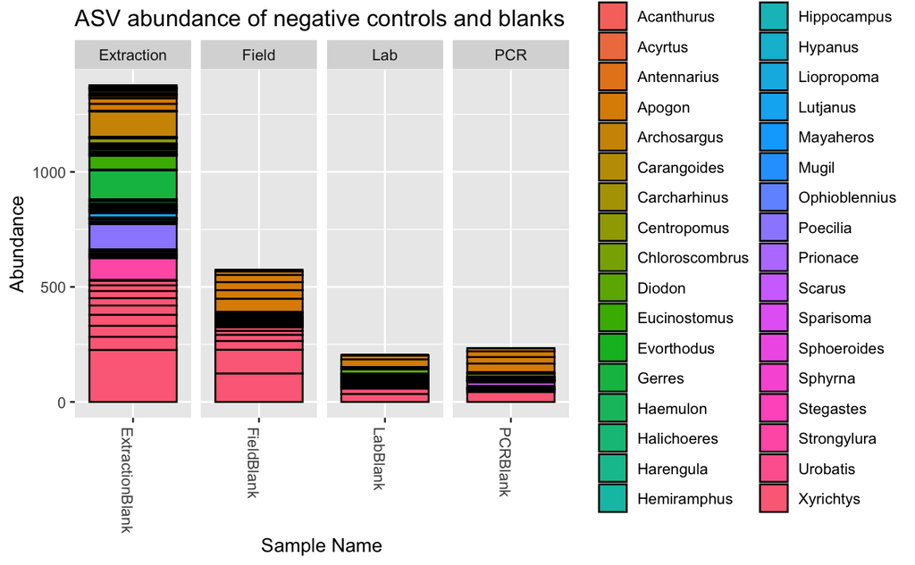

Before decontaminant removal

[output not shown]

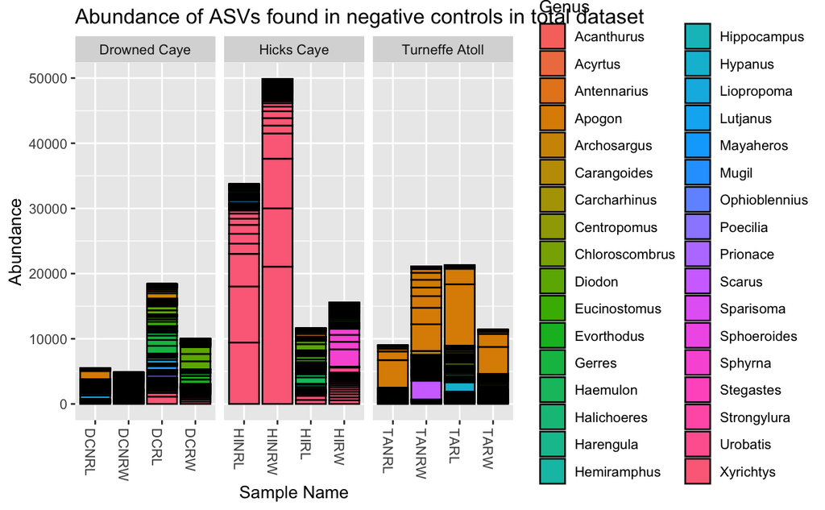

```r
ps.troph %>% subset_samples(Rookery!="Blank" & Rookery!="Practice") %>% prune_taxa(taxa_names(.)%in%taxa_names(ps.blanks),.) %>%
  plot_bar(x="SampleName_Short",fill="Genus") + facet_grid(~Site,scales="free") +
  labs(title="Abundance of ASVs found in negative controls in total dataset",x="Sample Name")
```

After decontaminant removal

[output not shown]

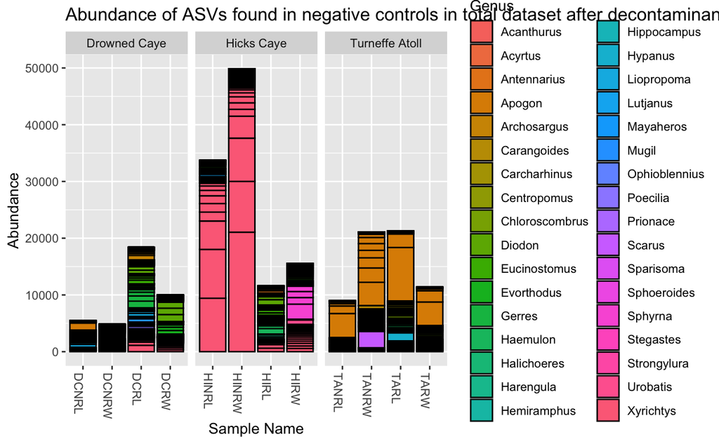

```r
decontam.ps.troph  %>% subset_samples(Rookery!="Blank" & Rookery!="Practice") %>% prune_taxa(taxa_names(.)%in%taxa_names(ps.blanks),.) %>%
  plot_bar(x="SampleName_Short",fill="Genus") + facet_grid(~Site,scales="free") +
  labs(title="Abundance of ASVs found in negative controls in total dataset after decontaminant removal",x="Sample Name")
```

After negative control ASV removal

[output not shown]

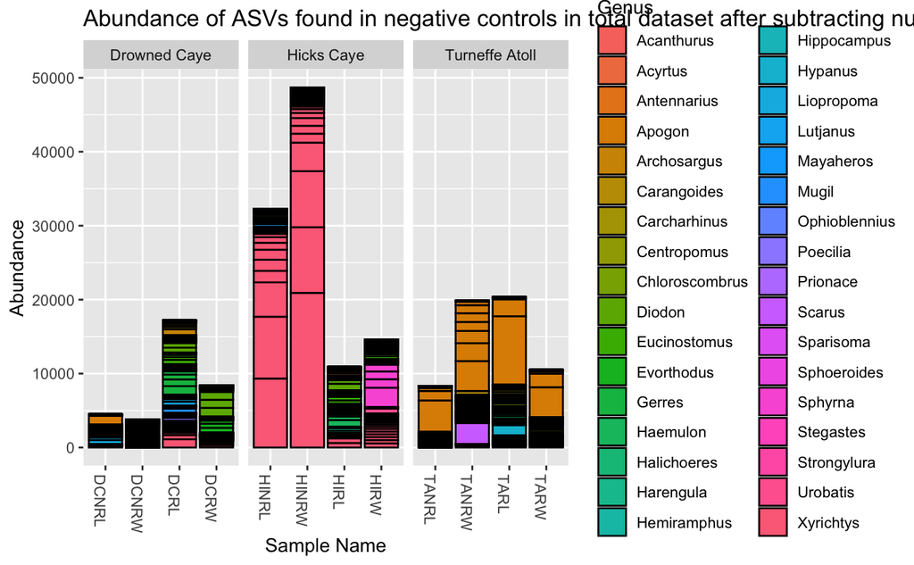

```r
prune.decontam.ps.troph %>% subset_samples(Rookery!="Blank" & Rookery!="Practice") %>% prune_taxa(taxa_names(.)%in%taxa_names(ps.blanks),.) %>%
  plot_bar(x="SampleName_Short",fill="Genus") + facet_grid(~Site,scales="free") +
  labs(title="Abundance of ASVs found in negative controls in total dataset after subtracting number of ASVs in negative controls ",x="Sample Name")
```

# Session Info

```r
saveRDS(decontam.ps.troph,paste0(dir_results,"/decontam.ps.troph.rds"))

saveRDS(prune_c.ps,paste0(dir_results,"/prune.decontam.ps.troph.keepblanks.rds"))
saveRDS(prune.decontam.ps.troph,paste0(dir_results,"/prune.decontam.ps.troph.rds"))
```

```r
save.image(paste0(dir_data,'/07_Blanks.RData'))
```

[output not shown]